# GEODES_Figures

Alex Linz

10/18/2018

# Metatranscriptomics reveals interactions between phototrophs and heterotrophs in freshwater

new plan: table 1: metadata table 2-4: categories by lake - add number of genes per category Figure 1: cyclic trends example Figure 2: barplots category by lake

table 2-4 plan: category| % expressed in day (genes/reads) | % expressed in night (genes/reads) | % cyclic

### Main text tables and figures.

**Table 1. Comparison of Sparkling Lake, Lake Mendota, and Trout Bog.** These three lakes were chosen for comparative metatranscriptomics because of their varying trophic statuses, extensive historical data, and previous microbial sampling. Data on surface area, maximum depth, and development on shoreline courtesy of NTL-LTER <lter.limnology.wisc.edu>. Temperature, dissolved oxygen, pH, and conductivity were measured using a HydroLab DS5x Sonde and are averaged over all sampling depths and timepoints for each lake. Chlorophyll and phycocyanin concentrations were measured from the integrated epilimnion samples using a methanol extraction protocol and averaged over all timepoints. Secchi depth was measured at the first timepoint for each lake. Bacterial production was quantified via C14-leucine incorporation and averaged over all timepoints. Due to thunderstorms the night of July 8th, the final 1AM timepoint in Sparkling Lake was collected on July 9th instead.

|  | Lake Mendota | Trout Bog | Sparkling Lake |
| --- | --- | --- | --- |
| Surface area (km^2) | 39.600 | 0.001 | 0.637 |
| Maximum depth (m) | 25.3 | 7.9 | 20.o |
| Trophic status | Eutrophic | Humic | Oligotrophic |
| Location | Madison, WI USA | Boulder Junction, WI USA | Boulder Junction, WI USA |
| GPS Coordinates | 43.1113, -89.4255 | 46.0412, -89.6861 | 46.0091, -89.6695 |
| Shoreline development | High | Low | Moderate |
| Epilimnion sampling depth | 0-7m | 0-1.5m | 0-4m |
| Temperature (C) | 24.61 | 19.51 | 23.33 |
| Dissolved oxygen (mg/L) | 9.71 | 5.33 | 9.25 |
| pH | 8.64 | 4.03 | 7.52 |
| Conductivity (uS/cm) | 608 | 25.87 | 174.54 |
| Total phosphorus (ug/L) | 18.81 | 23.17 | 6.44 |
| Total nitrogen (ug/L) | 625.83 | 667.98 | 346.46 |
| Total dissolved phosphorus (ug/L) | 8.83 | 15.41 | 5.42 |
| Total dissolved nitrogen (ug/L) | 506.7 | 587.51 | 305.17 |
| Chlorophyll (ug/L) | 6.14 | 14.44 | 1.77 |
| Phycocyanin (ug/L) | 0.74 | 1.94 | 3.15 |
| Bacterial production (cpm) | 60.02 | 30.3 | 3.15 |
| Secchi depth (m) | 4.8 | 1.1 | 6.2 |
| Sampling dates (2016) | July 14-16 | July 8-10 | July 6-9 |
| Sunrise/sunset time | 5:32/20:35 | 5:18/20:49 | 5:17/20:50 |

**Table 2.** Gene diffs in Lake Mendota

|  | % Number of genes | % Genes more expressed in day | % Reads in day contributed by those genes | % Genes more expressed at night | % Reads at night contributed by those genes | % Cyclic genes (12 hr phase) | % Reads contributed by cyclic genes | Mean reads in day samples | Mean reads in night samples |
| --- | --- | --- | --- | --- | --- | --- | --- | --- | --- |
| Photosynthesis | 637 | 46.47 | 84.46 | 30.61 | 30.89 | 21.51 | 85.06 | 7.26e+10 | 2.83e+10 |
| Rhodopsins | 124 | 29.03 | 44.68 | 22.58 | 28.88 | 13.71 | 51.68 | 3.68e+09 | 2.69e+09 |
| RuBisCO | 63 | 23.81 | 5.6 | 4.76 | 0.64 | 0 | 4.77 | 5.85e+09 | 5.08e+09 |
| reductive TCA | 14 | 7.14 | 12.07 | 21.43 | 17.58 | 0 | 18.36 | 2.05e+08 | 1.67e+08 |
| Nitrogenase | 5 | 0 | 0 | 0 | 0 | 0 | 0 | 3.96e+07 | 3.27e+07 |
| Polyamines | 51 | 0 | 0 | 43.14 | 55.87 | 0 | 49.64 | 5.31e+08 | 5.89e+08 |
| Chitinase | 4 | 0 | 0 | 50 | 71.65 | 0 | 60.22 | 1.30e+07 | 3.54e+07 |
| Alkaline phosphatase | 9 | 33.33 | 39.37 | 0 | 0 | 11.11 | 29.51 | 5.94e+07 | 5.15e+07 |
| Cellulase | 3 | 0 | 0 | 0 | 0 | 0 | 0 | 3.69e+07 | 3.63e+07 |
| Reactive oxygen species | 63 | 39.68 | 46.53 | 3.17 | 3.07 | 15.87 | 39.93 | 7.33e+08 | 4.17e+08 |
| Nitrite reduction | 4 | 25 | 50.44 | 0 | 0 | 25 | 36.33 | 2.52e+07 | 1.94e+07 |
| Protease | 252 | 20.63 | 20.07 | 5.16 | 8.71 | 7.54 | 20.29 | 3.10e+09 | 2.54e+09 |
| Carboxylate transport | 9 | 22.22 | 25.36 | 22.22 | 25.43 | 22.22 | 40.88 | 6.39e+07 | 5.34e+07 |
| Ribose transport | 28 | 0 | 0 | 46.43 | 65.71 | 0 | 62.18 | 3.32e+08 | 4.44e+08 |
| General sugar transport | 237 | 44.3 | 52.5 | 33.76 | 49.27 | 5.06 | 71.22 | 6.67e+09 | 4.80e+09 |
| Raffinose/stachyose/melibiose transport | 25 | 0 | 0 | 68 | 85.95 | 0 | 83.52 | 2.68e+08 | 4.61e+08 |
| Glucose/mannose transport | 36 | 0 | 0 | 16.67 | 17.02 | 0 | 16.38 | 4.86e+08 | 5.37e+08 |
| Rhamnose transport | 11 | 0 | 0 | 54.55 | 26.24 | 0 | 23.08 | 2.24e+08 | 2.66e+08 |
| Xylose transport | 45 | 2.22 | 2.64 | 6.67 | 5.35 | 0 | 6.62 | 5.62e+08 | 5.84e+08 |
| Fructose transport | 7 | 0 | 0 | 42.86 | 49.58 | 0 | 48.53 | 5.06e+07 | 6.32e+07 |
| Chitobiose transport | 2 | 0 | 0 | 50 | 54.13 | 0 | 44.94 | 1.78e+07 | 2.71e+07 |
| Lactose/arabinose transport | 8 | 0 | 0 | 100 | 100 | 0 | 100 | 3.40e+07 | 7.51e+07 |

**Table 3.** Gene diffs in Trout Bog

[output not shown]

**Table 3.** Gene diffs in Sparkling Lake

|  | % Number of genes | % Genes more expressed in day | % Reads in day contributed by those genes | % Genes more expressed at night | % Reads at night contributed by those genes | % Cyclic genes (12 hr phase) | % Reads contributed by cyclic genes | Mean reads in day samples | Mean reads in night samples |
| --- | --- | --- | --- | --- | --- | --- | --- | --- | --- |
| Photosynthesis | 573 | 30.89 | 80.64 | 10.47 | 4.32 | 16.23 | 73.45 | 5.37e+10 | 1.95e+10 |
| Rhodopsins | 95 | 6.32 | 4.01 | 1.05 | 0.75 | 2.11 | 2.66 | 1.09e+09 | 1.15e+09 |
| RuBisCO | 97 | 0 | 0 | 1.03 | 0.11 | 0 | 0.07 | 3.63e+09 | 5.47e+09 |
| reductive TCA | 6 | 33.33 | 58.98 | 0 | 0 | 0 | 24.51 | 2.89e+07 | 5.38e+07 |
| Nitrogenase | 4 | 25 | 37.12 | 0 | 0 | 0 | 35.83 | 2.80e+07 | 1.20e+07 |
| Polyamines | 23 | 4.35 | 4.5 | 13.04 | 17.96 | 0 | 17.77 | 1.38e+08 | 1.73e+08 |
| Chitinase | 8 | 0 | 0 | 0 | 0 | 0 | 0 | 5.10e+07 | 2.75e+07 |
| Alkaline phosphatase | 12 | 0 | 0 | 0 | 0 | 0 | 0 | 1.11e+08 | 1.80e+08 |
| Cellulase | 4 | 0 | 0 | 0 | 0 | 0 | 0 | 1.49e+07 | 1.76e+07 |
| Reactive oxygen species | 68 | 29.41 | 39.88 | 1.47 | 1.41 | 14.71 | 32.29 | 6.16e+08 | 3.29e+08 |
| Nitrite reduction | 2 | 50 | 55.69 | 0 | 0 | 50 | 49.3 | 2.27e+07 | 9.77e+06 |
| Protease | 278 | 10.79 | 11.79 | 0 | 0 | 2.16 | 8.23 | 2.80e+09 | 1.93e+09 |
| Carboxylate transport | 27 | 7.41 | 25.09 | 0 | 0 | 3.7 | 15.46 | 1.83e+08 | 1.46e+08 |
| Ribose transport | 13 | 0 | 0 | 7.69 | 7.44 | 0 | 6.23 | 8.37e+07 | 1.22e+08 |
| General sugar transport | 102 | 6.86 | 20.37 | 3.92 | 10.48 | 1.96 | 17.96 | 8.84e+08 | 1.00e+09 |
| Raffinose/stachyose/melibiose transport | 11 | 0 | 0 | 0 | 0 | 0 | 0 | 4.87e+07 | 9.14e+07 |
| Glucose/mannose transport | 15 | 0 | 0 | 0 | 0 | 0 | 0 | 1.07e+08 | 1.39e+08 |
| Rhamnose transport | 5 | 0 | 0 | 0 | 0 | 0 | 0 | 4.08e+07 | 5.01e+07 |
| Xylose transport | 17 | 0 | 0 | 0 | 0 | 0 | 0 | 9.65e+07 | 1.27e+08 |
| Fructose transport | 13 | 0 | 0 | 0 | 0 | 0 | 0 | 1.07e+08 | 1.56e+08 |
| Chitobiose transport | 1 | 0 | 0 | 0 | 0 | 0 | 0 | 1.97e+06 | 3.17e+06 |
| Methane/ammonia monooxygenase | 1 | 0 | 0 | 0 | 0 | 0 | 0 | 5.10e+06 | 6.93e+06 |
| Urease | 2 | 0 | 0 | 0 | 0 | 0 | 0 | 4.77e+06 | 1.06e+07 |

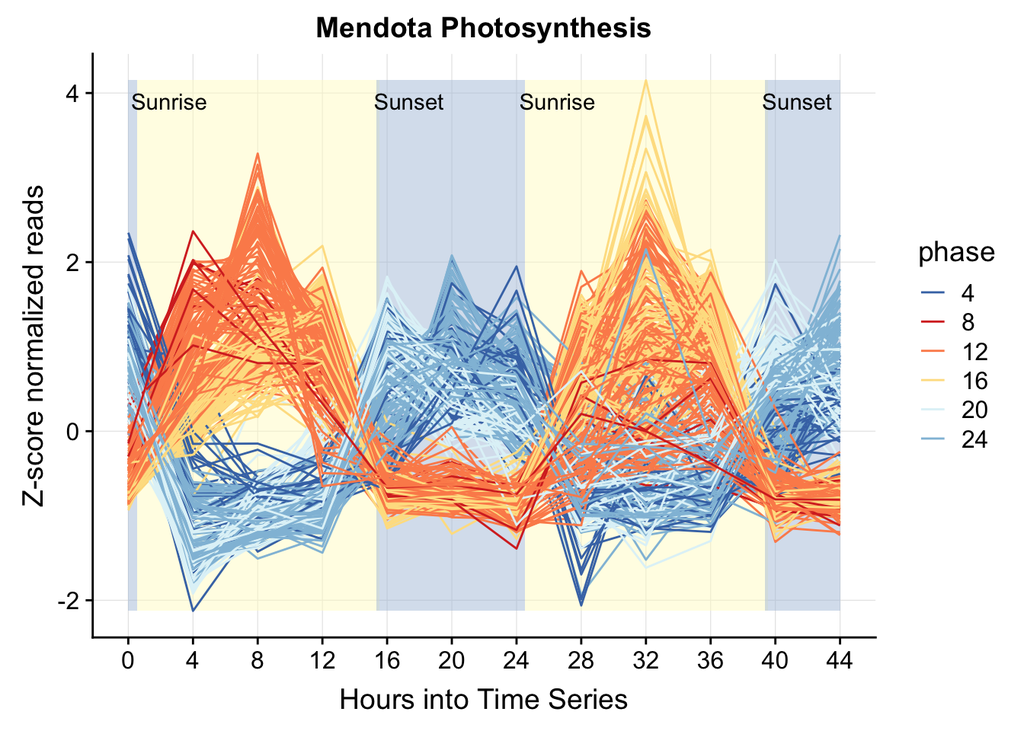

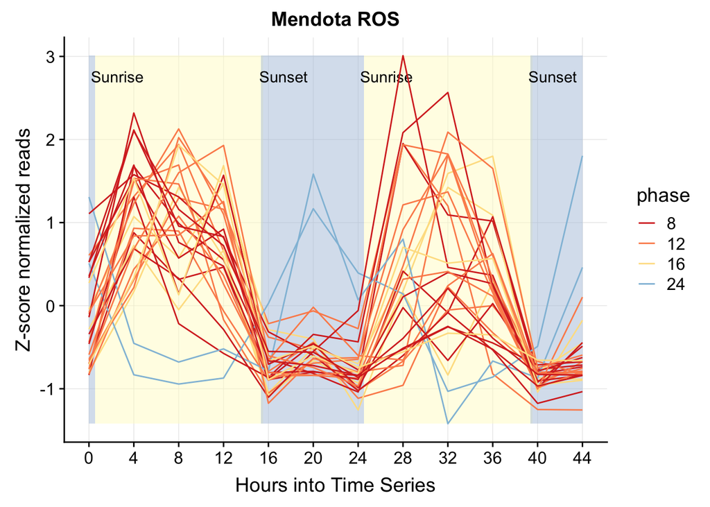

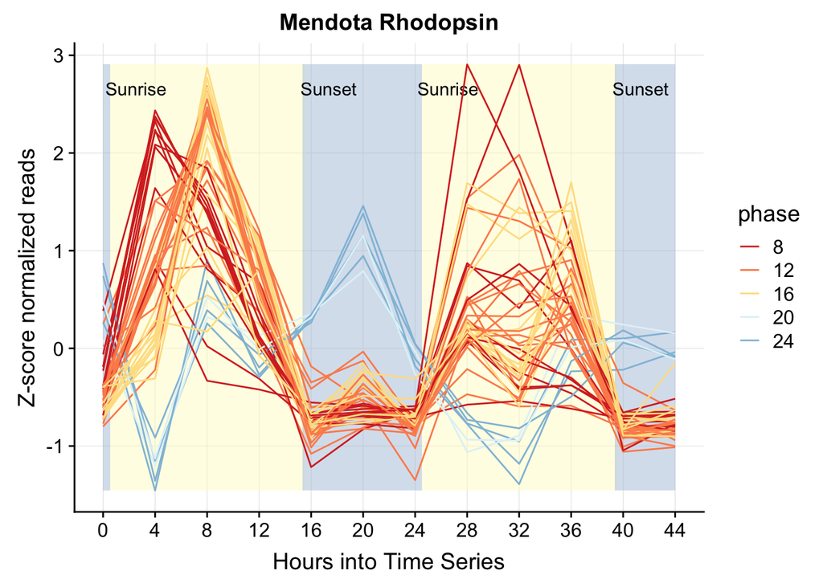

**Figure 1. Cyclic trends in Lake Mendota.** Cyclic trends with a 12 hour phase were detected in Lake Mendota for several functional categories.

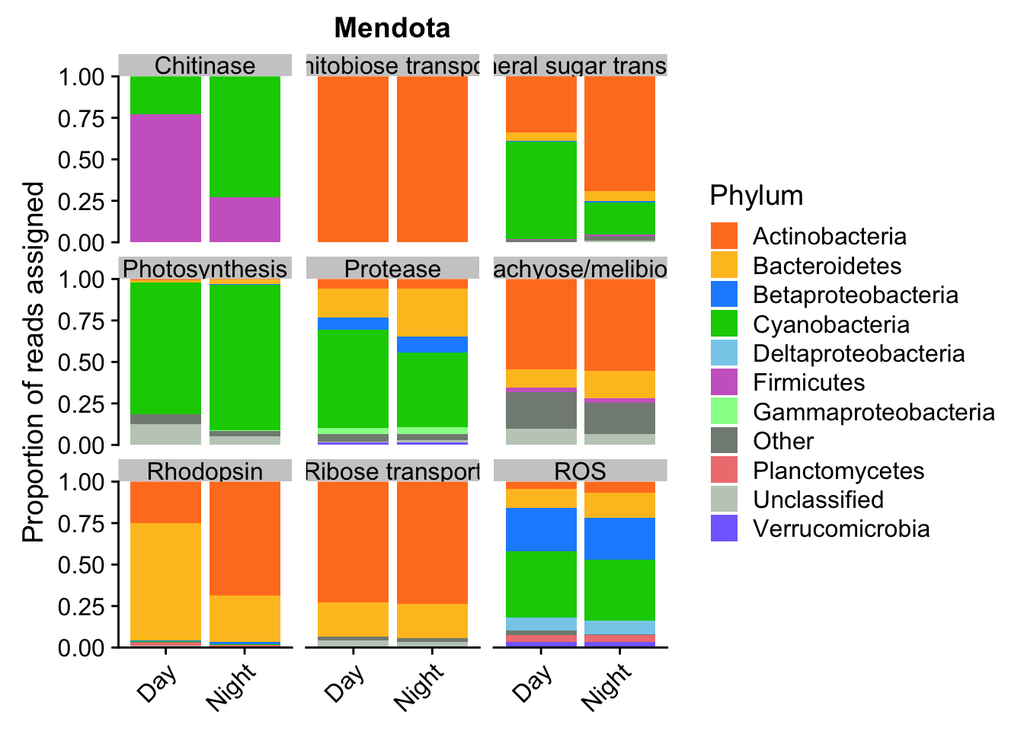